# Practical Machine Learning Course Project

Becky Reimer

10/27/2019

## Loading and preprocessing the data

First, I load the libraries needed for this project. Note that due to the amount of computing power needed to run models on the datasets provided, I am loading and using the parallel and doParallel libraries per suggestions from Len Greski (discussion forums mentor) provided here: https://github.com/lgreski/datasciencectacontent/blob/master/markdown/pml-randomForestPerformance.md

```r
library(caret)
library(parallel)
library(doParallel)
set.seed(444)
```

Next, I read in the .csv files containing the training and testing subsets of the exercise data. These data come from the weight lifting data described in the following paper:

Velloso, E.; Bulling, A.; Gellersen, H.; Ugulino, W.; Fuks, H. Qualitative Activity Recognition of Weight Lifting Exercises. Proceedings of 4th International Conference in Cooperation with SIGCHI (Augmented Human ’13) . Stuttgart, Germany: ACM SIGCHI, 2013.

```r
training_file <- read.csv("./pml-training.csv", na.strings = c("", "NA"))
testing_file <- read.csv("./pml-testing.csv", na.strings = c("", "NA"))
```

Next, I split the training file into a training and test set.

```r
inTrain <- createDataPartition(y=training_file$classe, p=0.75, list=FALSE)
training <- training_file[inTrain,]
testing <- training_file[-inTrain,]
dim(training); dim(testing)
```

```
## [1] 14718   160
```

```
## [1] 4904  160
```

Through some exploratory analysis, I found that these data have a lot of missing values. I counted these up to get a sense of just how many there are.

```r
var_miss <- colSums(is.na(training))
```

I see that many variables have missing values for the majority of the observations. Before creating models, I exclude those variables from the datasets.

```r
training_sub <- training[ , colSums(is.na(training)) == 0]
```

Then, I set up x and y syntax in preparation for running the model.

```r
x <- training_sub[,-60]
y <- training_sub[,60]
```

Next, I configure parallel processing and the trainControl object.

```r
cluster <- makeCluster(detectCores() - 1)
registerDoParallel(cluster)

fitControl <- trainControl(method = "cv", number = 5, allowParallel = TRUE)
```

Then I fit a training model using the random forests method. I selected the random forests method because this is a classification problem and this method should yield high accuracy. After the model has been created, I de-register teh parallel processing cluster.

```r
fit <- train(x, y, method="rf", data=training_sub, trControl = fitControl)

stopCluster(cluster)
registerDoSEQ()
```

Next, I take a look at the model and evaluate its accuracy and confusion matrix.

```r
fit
```

```
## Random Forest
##
## 14718 samples
##    59 predictor
##     5 classes: 'A', 'B', 'C', 'D', 'E'
##
## No pre-processing
## Resampling: Cross-Validated (5 fold)
## Summary of sample sizes: 11774, 11773, 11774, 11775, 11776
## Resampling results across tuning parameters:
##
##   mtry  Accuracy   Kappa
##    2    0.9991168  0.9988828
##   30    0.9997962  0.9997422
##   59    0.9995923  0.9994843
##
## Accuracy was used to select the optimal model using the largest value.
## The final value used for the model was mtry = 30.
```

```r
fit$resample
```

```
##    Accuracy     Kappa Resample
## 1 1.0000000 1.0000000    Fold1
## 2 0.9993207 0.9991407    Fold3
## 3 1.0000000 1.0000000    Fold2
## 4 1.0000000 1.0000000    Fold5
## 5 0.9996602 0.9995702    Fold4
```

```r
confusionMatrix.train(fit)
```

```
## Cross-Validated (5 fold) Confusion Matrix
##
## (entries are percentual average cell counts across resamples)
##
##           Reference
## Prediction    A    B    C    D    E
##          A 28.4  0.0  0.0  0.0  0.0
##          B  0.0 19.3  0.0  0.0  0.0
##          C  0.0  0.0 17.4  0.0  0.0
##          D  0.0  0.0  0.0 16.4  0.0
##          E  0.0  0.0  0.0  0.0 18.4
##
##  Accuracy (average) : 0.9998
```

This is a high level of accuracy for the training set. Next, I create predictions for the testing set, and plot the predictions against the true values for the classe variable.

```r
pred1 <- predict(fit, testing)
confusionMatrix(pred1,testing$classe)
```

```
## Confusion Matrix and Statistics
##
##           Reference
## Prediction    A    B    C    D    E
##          A 1395    0    0    0    0
##          B    0  949    0    0    0
##          C    0    0  855    0    0
##          D    0    0    0  804    1
##          E    0    0    0    0  900
##
## Overall Statistics
##
##                Accuracy : 0.9998
##                  95% CI : (0.9989, 1)
##     No Information Rate : 0.2845
##     P-Value [Acc > NIR] : < 2.2e-16
##
##                   Kappa : 0.9997
##
##  Mcnemar's Test P-Value : NA
##
## Statistics by Class:
##
##                      Class: A Class: B Class: C Class: D Class: E
## Sensitivity            1.0000   1.0000   1.0000   1.0000   0.9989
## Specificity            1.0000   1.0000   1.0000   0.9998   1.0000
## Pos Pred Value         1.0000   1.0000   1.0000   0.9988   1.0000
## Neg Pred Value         1.0000   1.0000   1.0000   1.0000   0.9998
## Prevalence             0.2845   0.1935   0.1743   0.1639   0.1837
## Detection Rate         0.2845   0.1935   0.1743   0.1639   0.1835
## Detection Prevalence   0.2845   0.1935   0.1743   0.1642   0.1835
## Balanced Accuracy      1.0000   1.0000   1.0000   0.9999   0.9994
```

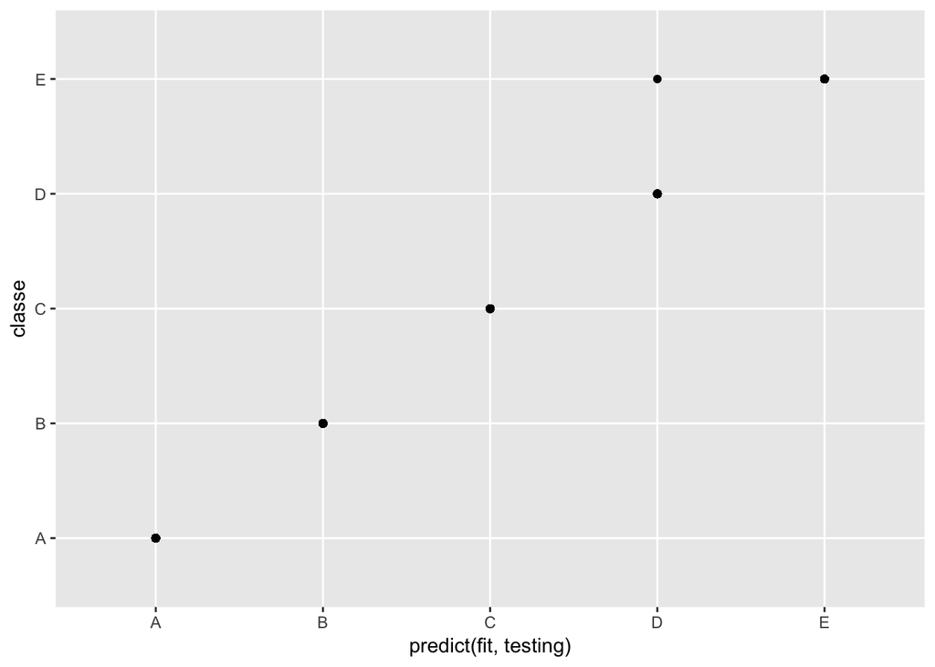

```r
qplot(predict(fit, testing), classe, data=testing)
```

This shows that the random forests model is incredibly accurate in predicting whether the test subjects were conducting the weight lifting exercises correctly or making the specified types of mistakes.